# Prediction on Weight Lifting Exercises

Zongyuan He

18 Jan 2015

## Summary

Smart wearable devices like Jawbone Up, Nike FuelBand, and Fitbit allows people to record their physical activity easily. However, few research was conducted on the quality of recorded physical activity. This analysis involved 6 participants, who were asked to perform barbell lifts correctly and incorrectly in 5 different ways. The machine learning algorithm developed based on the recorded data could distinguish the types of barbell lifts very well.

## Co-variate Creation

In this analysis we will use WLE[1] data set to perform the model fitting.

First, we load the pre-processed data and perform some exploratory analysis.

```r
if(file.access("pml-training.csv", mode = 4) == -1){
    download.file("https://d396qusza40orc.cloudfront.net/predmachlearn/pml-training.csv", "pml-training.csv", method="curl")
    }
pml_training <- read.csv("pml-training.csv")
```

Training data set contains 19622 observations and 160 variables. As we were going to construct a machine learning algorithm, the data set were cleaned by following steps:

1. Removed covariate that has over 95% missing values. With so much high missing value rate, imputing missing values may do nothing good but introducing higher bias.
2. Removed covariate that is near zero varience.

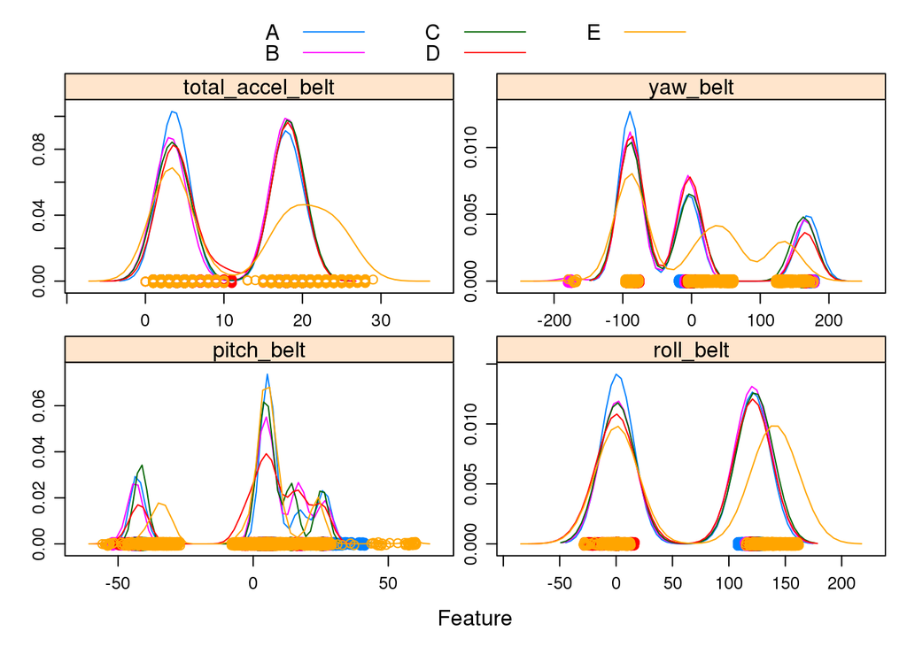

```r
library(caret, quietly = TRUE)

#Remove covariates that have over 95% of missing values.
nearNaVar <- function (data, NaRatio = 0.95){
    Nas <- c()
    for (i in seq_along(data)) {
        if ( sum(is.na(data[i]))/nrow(data[i]) >= NaRatio) {
            Nas <- c(Nas, i)
        }
    }
    return(Nas)
}
nnv <- nearNaVar(pml_training)
pml_training <- pml_training[,-nnv]

#Remove covariates that have near zero variance.
nsv <- nearZeroVar(pml_training)
pml_training <- pml_training[,-nsv]

#Remove index and time sequence variables that are not helpful for predicting.
pml_training <- pml_training[,-(1:6)]

##Draw plot for exploration
featurePlot(pml_training[,1:4], pml_training$classe, plot="density", scales = list(x=list(relation="free"), y=list(relation="free")), adjust =1.5, auto.key=list(columns=3))
```

Additionally, time sequence marks were considered as irrelevant in above steps after considering the experiment precedures.

## Model Building

The cleaned data was separated into two sub-groups for method training and testing.

```r
#Set random seed for reproducibility
set.seed(38423)

#Divide original data into training
inTrain <- createDataPartition(pml_training$classe, p = 0.7, list = FALSE)
training <- pml_training[inTrain,]
testing <- pml_training[-inTrain,]
```

The resulted training sub-group contains 13737 observations while the testing contains 5885. Because the explorationn analysis suggests a non-liner patten of the covariates, tree method was deployed firstly.

```r
modelTree <- train(training$classe ~., data = training, method = "rpart")
modelTree
```

```
## CART
##
## 13737 samples
##    52 predictor
##     5 classes: 'A', 'B', 'C', 'D', 'E'
##
## No pre-processing
## Resampling: Bootstrapped (25 reps)
##
## Summary of sample sizes: 13737, 13737, 13737, 13737, 13737, 13737, ...
##
## Resampling results across tuning parameters:
##
##   cp          Accuracy   Kappa       Accuracy SD  Kappa SD
##   0.03590683  0.5131225  0.36736845  0.01389838   0.02206063
##   0.06025159  0.4117978  0.20036963  0.06120967   0.10417366
##   0.11280643  0.3102626  0.03916134  0.03778052   0.05828929
##
## Accuracy was used to select the optimal model using  the largest value.
## The final value used for the model was cp = 0.03590683.
```

```r
library(rattle)
```

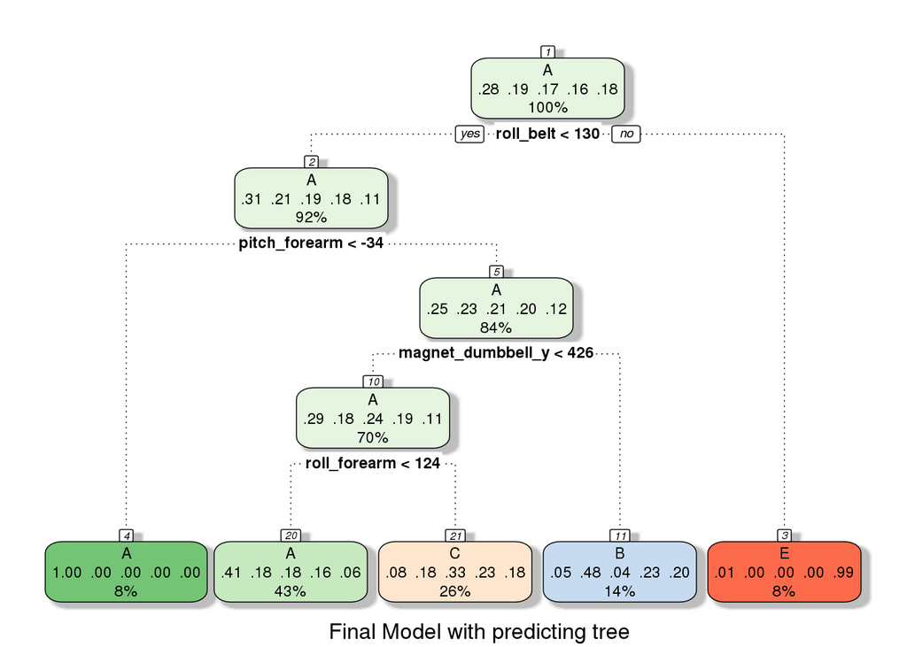

```r
fancyRpartPlot(modelTree$finalModel, sub = "Final Model with predicting tree")
```

Reported accuracy of tree model is rather low(Acc = 0.51) with 25 bootstrapped resampling. Furthermore, the final tree falied to classify the “D” class. With this in mind, we continued to apply more robust random forest method. “doMC” packages was used to take advantage of the parallel processing.

```r
library(doMC, quietly = TRUE)
registerDoMC() #Utilize half of available cores for parallel processing.
fitControl <- trainControl(method = "oob", allowParallel = TRUE)
modelForest <- train(training$classe ~., data = training, method = "rf", trControl = fitControl, allowParallel = TRUE)
modelForest
```

```
## Random Forest
##
## 13737 samples
##    52 predictor
##     5 classes: 'A', 'B', 'C', 'D', 'E'
##
## No pre-processing
## Resampling results across tuning parameters:
##
##   mtry  Accuracy   Kappa
##    2    0.9924292  0.9904222
##   27    0.9933756  0.9916197
##   52    0.9871151  0.9836990
##
## Accuracy was used to select the optimal model using  the largest value.
## The final value used for the model was mtry = 27.
```

Reported accuracy is quite high(Acc = 0.99) thus a low out of bag error rate is expected. Cross-validation isn’t necessary for random forest to get a unbiasd estimate as suggested by package maintainer[2].

## Model Testing and Selection

```r
modelForest$finalModel
```

```
##
## Call:
##  randomForest(x = x, y = y, mtry = param$mtry, allowParallel = TRUE)
##                Type of random forest: classification
##                      Number of trees: 500
## No. of variables tried at each split: 27
##
##         OOB estimate of  error rate: 0.69%
## Confusion matrix:
##      A    B    C    D    E class.error
## A 3902    2    1    0    1 0.001024066
## B   21 2632    4    1    0 0.009781791
## C    0   14 2374    8    0 0.009181970
## D    0    1   25 2224    2 0.012433393
## E    0    1    5    9 2510 0.005940594
```

```r
confusionMatrix(predict(modelForest$finalModel, newdata = testing), testing$classe)
```

```
## Confusion Matrix and Statistics
##
##           Reference
## Prediction    A    B    C    D    E
##          A 1674    9    0    0    0
##          B    0 1124    2    1    0
##          C    0    6 1017    7    0
##          D    0    0    7  955    3
##          E    0    0    0    1 1079
##
## Overall Statistics
##
##                Accuracy : 0.9939
##                  95% CI : (0.9915, 0.9957)
##     No Information Rate : 0.2845
##     P-Value [Acc > NIR] : < 2.2e-16
##
##                   Kappa : 0.9923
##  Mcnemar's Test P-Value : NA
##
## Statistics by Class:
##
##                      Class: A Class: B Class: C Class: D Class: E
## Sensitivity            1.0000   0.9868   0.9912   0.9907   0.9972
## Specificity            0.9979   0.9994   0.9973   0.9980   0.9998
## Pos Pred Value         0.9947   0.9973   0.9874   0.9896   0.9991
## Neg Pred Value         1.0000   0.9968   0.9981   0.9982   0.9994
## Prevalence             0.2845   0.1935   0.1743   0.1638   0.1839
## Detection Rate         0.2845   0.1910   0.1728   0.1623   0.1833
## Detection Prevalence   0.2860   0.1915   0.1750   0.1640   0.1835
## Balanced Accuracy      0.9989   0.9931   0.9943   0.9943   0.9985
```

## Model Validation

Similarly, we loaded the pre-processed testing data to validate the chosen prediction model. The exact data cleaning precedures were applied.

```r
if(file.access("pml-testing.csv", mode = 4) == -1){
    download.file("https://d396qusza40orc.cloudfront.net/predmachlearn/pml-testing.csv", "pml-testing.csv", method="curl")
    }
pml_testing <- read.csv("pml-testing.csv")
pml_testing <- pml_testing[,-nnv]
pml_testing <- pml_testing[,-nsv]
pml_testing <- pml_testing[,-(1:6)]
answers <- predict(modelFit$finalModel, newdata = pml_testing)
answers
```

[output not shown]

## Result Submission

```r
pml_write_files = function(x){
  n = length(x)
  for(i in 1:n){
    filename = paste0("problem_id_",i,".txt")
    write.table(x[i],file=filename,quote=FALSE,row.names=FALSE,col.names=FALSE)
  }
}
pml_write_files(answers)
```

## Reference

[1] Velloso, E.; Bulling, A.; Gellersen, H.; Ugulino, W.; Fuks, H. Qualitative Activity Recognition of Weight Lifting Exercises. Proceedings of 4th International Conference in Cooperation with SIGCHI (Augmented Human ’13) . Stuttgart, Germany: ACM SIGCHI, 2013.

Read more: http://groupware.les.inf.puc-rio.br/har#ixzz3PA56n1ax

[2] http://www.stat.berkeley.edu/~breiman/RandomForests/cc_home.htm#ooberr